# Part I - (Prosper Loan Data)

## by (Ijeoma Mariam Okocha - mariokocha@gmail.com)

## Introduction

> This data set contains 113,937 loans with 81 variables on each loan, including loan amount, borrower rate (or interest rate), current loan status, borrower income, and many others. Where the variables and its description is given below:
1. ListingKey -- Unique key for each listing, same value as the 'key' used in the listing object in the API.
2. ListingNumber -- The number that uniquely identifies the listing to the public as displayed on the website.
3. ListingCreationDate -- The date the listing was created.
4. CreditGrade -- The Credit rating that was assigned at the time the listing went live. Applicable for listings pre-2009 period and will only be populated for those listings.
5. Term -- The length of the loan expressed in months.
6. LoanStatus -- The current status of the loan: Cancelled, Chargedoff, Completed, Current, Defaulted, FinalPaymentInProgress, PastDue. The PastDue status will be accompanied by a delinquency bucket.
7. ClosedDate -- Closed date is applicable for Cancelled, Completed, Chargedoff and Defaulted loan statuses.
8. BorrowerAPR -- The Borrower's Annual Percentage Rate (APR) for the loan.
9. BorrowerRate -- The Borrower's interest rate for this loan.
10. LenderYield -- The Lender yield on the loan. Lender yield is equal to the interest rate on the loan less the servicing fee.
11. EstimatedEffectiveYield -- Effective yield is equal to the borrower interest rate (i) minus the servicing fee rate, (ii) minus estimated uncollected interest on charge-offs, (iii) plus estimated collected late fees. Applicable for loans originated after July 2009.
12. EstimatedLoss -- Estimated loss is the estimated principal loss on charge-offs. Applicable for loans originated after July 2009.
13. EstimatedReturn -- The estimated return assigned to the listing at the time it was created. Estimated return is the difference between the Estimated Effective Yield and the Estimated Loss Rate. Applicable for loans originated after July 2009.
14. ProsperRating (numeric) -- The Prosper Rating assigned at the time the listing was created: 0 - N/A, 1 - HR, 2 - E, 3 - D, 4 - C, 5 - B, 6 - A, 7 - AA. Applicable for loans originated after July 2009.
15. ProsperRating (Alpha) -- The Prosper Rating assigned at the time the listing was created between AA - HR. Applicable for loans originated after July 2009.
16. ProsperScore -- A custom risk score built using historical Prosper data. The score ranges from 1-10, with 10 being the best, or lowest risk score. Applicable for loans originated after July 2009.
17. ListingCategory (numeric) -- The category of the listing that the borrower selected when posting their listing: 0 - Not Available, 1 - Debt Consolidation, 2 - Home Improvement, 3 - Business, 4 - Personal Loan, 5 - Student Use, 6 - Auto, 7- Other, 8 - Baby&Adoption, 9 - Boat, 10 - Cosmetic Procedure, 11 - Engagement Ring, 12 - Green Loans, 13 - Household Expenses, 14 - Large Purchases, 15 - Medical/Dental, 16 - Motorcycle, 17 - RV, 18 - Taxes, 19 - Vacation, 20 - Wedding Loans
18. BorrowerState -- The two letter abbreviation of the state of the address of the borrower at the time the Listing was created.
19. Occupation -- The Occupation selected by the Borrower at the time they created the listing.
20. EmploymentStatus -- The employment status of the borrower at the time they posted the listing.
21. EmploymentStatusDuration -- The length in months of the employment status at the time the listing was created.
22. IsBorrowerHomeowner -- A Borrower will be classified as a homowner if they have a mortgage on their credit profile or provide documentation confirming they are a homeowner.
23. CurrentlyInGroup -- Specifies whether or not the Borrower was in a group at the time the listing was created.
24. GroupKey -- The Key of the group in which the Borrower is a member of. Value will be null if the borrower does not have a group affiliation.
25. DateCreditPulled -- The date the credit profile was pulled.
26. CreditScoreRangeLower -- The lower value representing the range of the borrower's credit score as provided by a consumer credit rating agency.
27. CreditScoreRangeUpper -- The upper value representing the range of the borrower's credit score as provided by a consumer credit rating agency.
28. FirstRecordedCreditLine -- The date the first credit line was opened.
29. CurrentCreditLines -- Number of current credit lines at the time the credit profile was pulled.
30. OpenCreditLines -- Number of open credit lines at the time the credit profile was pulled.
31. TotalCreditLinespast7years -- Number of credit lines in the past seven years at the time the credit profile was pulled.
32. OpenRevolvingAccounts -- Number of open revolving accounts at the time the credit profile was pulled.
33. OpenRevolvingMonthlyPayment -- Monthly payment on revolving accounts at the time the credit profile was pulled.
34. InquiriesLast6Months -- Number of inquiries in the past six months at the time the credit profile was pulled.
35. TotalInquiries -- Total number of inquiries at the time the credit profile was pulled.
36. CurrentDelinquencies -- Number of accounts delinquent at the time the credit profile was pulled.
37. AmountDelinquent -- Dollars delinquent at the time the credit profile was pulled.
38. DelinquenciesLast7Years -- Number of delinquencies in the past 7 years at the time the credit profile was pulled.
39. PublicRecordsLast10Years -- Number of public records in the past 10 years at the time the credit profile was pulled.
40. PublicRecordsLast12Months -- Number of public records in the past 12 months at the time the credit profile was pulled.
41. RevolvingCreditBalance -- Dollars of revolving credit at the time the credit profile was pulled.
42. BankcardUtilization -- The percentage of available revolving credit that is utilized at the time the credit profile was pulled.
43. AvailableBankcardCredit -- The total available credit via bank card at the time the credit profile was pulled.
44. TotalTrades -- Number of trade lines ever opened at the time the credit profile was pulled.
45. TradesNeverDelinquent (percentage) -- Number of trades that have never been delinquent at the time the credit profile was pulled.
46. TradesOpenedLast6Months -- Number of trades opened in the last 6 months at the time the credit profile was pulled.
47. DebtToIncomeRatio -- The debt to income ratio of the borrower at the time the credit profile was pulled. This value is Null if the debt to income ratio is not available. This value is capped at 10.01 (any debt to income ratio larger than 1000% will be returned as 1001%).
48. IncomeRange -- The income range of the borrower at the time the listing was created.
49. IncomeVerifiable -- The borrower indicated they have the required documentation to support their income.
50. StatedMonthlyIncome -- The monthly income the borrower stated at the time the listing was created.
51. LoanKey -- Unique key for each loan. This is the same key that is used in the API.
52. TotalProsperLoans -- Number of Prosper loans the borrower at the time they created this listing. This value will be null if the borrower had no prior loans.
53. TotalProsperPaymentsBilled -- Number of on time payments the borrower made on Prosper loans at the time they created this listing. This value will be null if the borrower had no prior loans.
54. OnTimeProsperPayments -- Number of on time payments the borrower had made on Prosper loans at the time they created this listing. This value will be null if the borrower has no prior loans.
55. ProsperPaymentsLessThanOneMonthLate -- Number of payments the borrower made on Prosper loans that were less than one month late at the time they created this listing. This value will be null if the borrower had no prior loans.
56. ProsperPaymentsOneMonthPlusLate -- Number of payments the borrower made on Prosper loans that were greater than one month late at the time they created this listing. This value will be null if the borrower had no prior loans.
57. ProsperPrincipalBorrowed -- Total principal borrowed on Prosper loans at the time the listing was created. This value will be null if the borrower had no prior loans.
58. ProsperPrincipalOutstanding -- Principal outstanding on Prosper loans at the time the listing was created. This value will be null if the borrower had no prior loans.
59. ScorexChangeAtTimeOfListing -- Borrower's credit score change at the time the credit profile was pulled. This will be the change relative to the borrower's last Prosper loan. This value will be null if the borrower had no prior loans.
60. LoanCurrentDaysDelinquent -- The number of days delinquent.
61. LoanFirstDefaultedCycleNumber -- The cycle the loan was charged off. If the loan has not charged off the value will be null.
62. LoanMonthsSinceOrigination -- Number of months since the loan originated.
63. LoanNumber -- Unique numeric value associated with the loan.
64. LoanOriginalAmount -- The origination amount of the loan.
65. LoanOriginationDate -- The date the loan was originated.
66. LoanOriginationQuarter -- The quarter in which the loan was originated.
67. MemberKey -- The unique key that is associated with the borrower. This is the same identifier that is used in the API member object.
68. MonthlyLoanPayment -- The scheduled monthly loan payment.
69. LP_CustomerPayments -- Pre charge-off cumulative gross payments made by the borrower on the loan. If the loan has charged off, this value will exclude any recoveries.
70. LP_CustomerPrincipalPayments -- Pre charge-off cumulative principal payments made by the borrower on the loan. If the loan has charged off, this value will exclude any recoveries.
71. LP_InterestandFees -- Pre charge-off cumulative interest and fees paid by the borrower. If the loan has charged off, this value will exclude any recoveries.
72. LP_ServiceFees -- Cumulative service fees paid by the investors who have invested in the loan. 4
73. LP_CollectionFees -- Cumulative collection fees paid by the investors who have invested in the loan.
74. LP_GrossPrincipalLoss -- The gross charged off amount of the loan.
75. LP_NetPrincipalLoss -- The principal that remains uncollected after any recoveries.
76. LP_NonPrincipalRecoverypayments -- The interest and fee component of any recovery payments. The current payment policy applies payments in the following order: Fees, interest, principal.
77. PercentFunded -- Percent the listing was funded.
78. Recommendations -- Number of recommendations the borrower had at the time the listing was created.
79. InvestmentFromFriendsCount -- Number of friends that made an investment in the loan.
80. InvestmentFromFriendsAmount -- Dollar amount of investments that were made by friends.
81. Investors -- The number of investors that funded the loan.

## Preliminary Wrangling

```python
# import all packages and set plots to be embedded inline
import numpy as np
import pandas as pd
import matplotlib.pyplot as plt
import seaborn as sb

%matplotlib inline
```

```python
loans = pd.read_csv('prosperLoanData.csv')
loan= loans.copy()
loan.head(10)
```

|  | ListingKey | ListingNumber | ListingCreationDate | CreditGrade | Term | LoanStatus | ClosedDate | BorrowerAPR | BorrowerRate | LenderYield | ... | LP_ServiceFees | LP_CollectionFees | LP_GrossPrincipalLoss | LP_NetPrincipalLoss | LP_NonPrincipalRecoverypayments | PercentFunded | Recommendations | InvestmentFromFriendsCount | InvestmentFromFriendsAmount | Investors |
| --- | --- | --- | --- | --- | --- | --- | --- | --- | --- | --- | --- | --- | --- | --- | --- | --- | --- | --- | --- | --- | --- |
| 0 | 1021339766868145413AB3B | 193129 | 2007-08-26 19:09:29.263000000 | C | 36 | Completed | 2009-08-14 00:00:00 | 0.16516 | 0.1580 | 0.1380 | ... | -133.18 | 0.0 | 0.0 | 0.0 | 0.0 | 1.0 | 0 | 0 | 0.0 | 258 |
| 1 | 10273602499503308B223C1 | 1209647 | 2014-02-27 08:28:07.900000000 | NaN | 36 | Current | NaN | 0.12016 | 0.0920 | 0.0820 | ... | 0.00 | 0.0 | 0.0 | 0.0 | 0.0 | 1.0 | 0 | 0 | 0.0 | 1 |
| 2 | 0EE9337825851032864889A | 81716 | 2007-01-05 15:00:47.090000000 | HR | 36 | Completed | 2009-12-17 00:00:00 | 0.28269 | 0.2750 | 0.2400 | ... | -24.20 | 0.0 | 0.0 | 0.0 | 0.0 | 1.0 | 0 | 0 | 0.0 | 41 |
| 3 | 0EF5356002482715299901A | 658116 | 2012-10-22 11:02:35.010000000 | NaN | 36 | Current | NaN | 0.12528 | 0.0974 | 0.0874 | ... | -108.01 | 0.0 | 0.0 | 0.0 | 0.0 | 1.0 | 0 | 0 | 0.0 | 158 |
| 4 | 0F023589499656230C5E3E2 | 909464 | 2013-09-14 18:38:39.097000000 | NaN | 36 | Current | NaN | 0.24614 | 0.2085 | 0.1985 | ... | -60.27 | 0.0 | 0.0 | 0.0 | 0.0 | 1.0 | 0 | 0 | 0.0 | 20 |
| 5 | 0F05359734824199381F61D | 1074836 | 2013-12-14 08:26:37.093000000 | NaN | 60 | Current | NaN | 0.15425 | 0.1314 | 0.1214 | ... | -25.33 | 0.0 | 0.0 | 0.0 | 0.0 | 1.0 | 0 | 0 | 0.0 | 1 |
| 6 | 0F0A3576754255009D63151 | 750899 | 2013-04-12 09:52:56.147000000 | NaN | 36 | Current | NaN | 0.31032 | 0.2712 | 0.2612 | ... | -22.95 | 0.0 | 0.0 | 0.0 | 0.0 | 1.0 | 0 | 0 | 0.0 | 1 |
| 7 | 0F1035772717087366F9EA7 | 768193 | 2013-05-05 06:49:27.493000000 | NaN | 36 | Current | NaN | 0.23939 | 0.2019 | 0.1919 | ... | -69.21 | 0.0 | 0.0 | 0.0 | 0.0 | 1.0 | 0 | 0 | 0.0 | 1 |
| 8 | 0F043596202561788EA13D5 | 1023355 | 2013-12-02 10:43:39.117000000 | NaN | 36 | Current | NaN | 0.07620 | 0.0629 | 0.0529 | ... | -16.77 | 0.0 | 0.0 | 0.0 | 0.0 | 1.0 | 0 | 0 | 0.0 | 1 |
| 9 | 0F043596202561788EA13D5 | 1023355 | 2013-12-02 10:43:39.117000000 | NaN | 36 | Current | NaN | 0.07620 | 0.0629 | 0.0529 | ... | -16.77 | 0.0 | 0.0 | 0.0 | 0.0 | 1.0 | 0 | 0 | 0.0 | 1 |

10 rows × 81 columns

```python
loan.info()
```

```
<class 'pandas.core.frame.DataFrame'>
RangeIndex: 113937 entries, 0 to 113936
Data columns (total 81 columns):
 #   Column                               Non-Null Count   Dtype
---  ------                               --------------   -----
 0   ListingKey                           113937 non-null  object
 1   ListingNumber                        113937 non-null  int64
 2   ListingCreationDate                  113937 non-null  object
 3   CreditGrade                          28953 non-null   object
 4   Term                                 113937 non-null  int64
 5   LoanStatus                           113937 non-null  object
 6   ClosedDate                           55089 non-null   object
 7   BorrowerAPR                          113912 non-null  float64
 8   BorrowerRate                         113937 non-null  float64
 9   LenderYield                          113937 non-null  float64
```

[output cut: 73 more lines]

```python
# descriptive statistics for numeric variables
print(loan.describe())
#we can see there are 61 numnerical data set,3 boolean set and the rest Objects
```

```
       ListingNumber           Term    BorrowerAPR   BorrowerRate  \
count   1.139370e+05  113937.000000  113912.000000  113937.000000
mean    6.278857e+05      40.830248       0.218828       0.192764
std     3.280762e+05      10.436212       0.080364       0.074818
min     4.000000e+00      12.000000       0.006530       0.000000
25%     4.009190e+05      36.000000       0.156290       0.134000
50%     6.005540e+05      36.000000       0.209760       0.184000
75%     8.926340e+05      36.000000       0.283810       0.250000
max     1.255725e+06      60.000000       0.512290       0.497500

         LenderYield  EstimatedEffectiveYield  EstimatedLoss  EstimatedReturn  \
count  113937.000000             84853.000000   84853.000000     84853.000000
mean        0.182701                 0.168661       0.080306         0.096068
std         0.074516                 0.068467       0.046764         0.030403
min        -0.010000                -0.182700       0.004900        -0.182700
25%         0.124200                 0.115670       0.042400         0.074080
50%         0.173000                 0.161500       0.072400         0.091700
75%         0.240000                 0.224300       0.112000         0.116600
max         0.492500                 0.319900       0.366000         0.283700

       ProsperRating (numeric)  ProsperScore  ...  LP_ServiceFees  \
count             84853.000000  84853.000000  ...   113937.000000
mean                  4.072243      5.950067  ...      -54.725641
std                   1.673227      2.376501  ...       60.675425
min                   1.000000      1.000000  ...     -664.870000
25%                   3.000000      4.000000  ...      -73.180000
50%                   4.000000      6.000000  ...      -34.440000
75%                   5.000000      8.000000  ...      -13.920000
max                   7.000000     11.000000  ...       32.060000

       LP_CollectionFees  LP_GrossPrincipalLoss  LP_NetPrincipalLoss  \
count      113937.000000          113937.000000        113937.000000
mean          -14.242698             700.446342           681.420499
std           109.232758            2388.513831          2357.167068
min         -9274.750000             -94.200000          -954.550000
25%             0.000000               0.000000             0.000000
50%             0.000000               0.000000             0.000000
75%             0.000000               0.000000             0.000000
max             0.000000           25000.000000         25000.000000

       LP_NonPrincipalRecoverypayments  PercentFunded  Recommendations  \
count                    113937.000000  113937.000000    113937.000000
mean                         25.142686       0.998584         0.048027
std                         275.657937       0.017919         0.332353
min                           0.000000       0.700000         0.000000
25%                           0.000000       1.000000         0.000000
50%                           0.000000       1.000000         0.000000
75%                           0.000000       1.000000         0.000000
max                       21117.900000       1.012500        39.000000

       InvestmentFromFriendsCount  InvestmentFromFriendsAmount      Investors
count               113937.000000                113937.000000  113937.000000
mean                     0.023460                    16.550751      80.475228
std                      0.232412                   294.545422     103.239020
min                      0.000000                     0.000000       1.000000
25%                      0.000000                     0.000000       2.000000
50%                      0.000000                     0.000000      44.000000
75%                      0.000000                     0.000000     115.000000
max                     33.000000                 25000.000000    1189.000000

[8 rows x 61 columns]
```

```python
# convert into ordered categorical types
ordinal_var_dict = {'LoanStatus': ['Cancelled','Chargedoff','Completed','Current','Defaulted','FinalPaymentInProgress','PastDue'],
                    'ProsperRating (Alpha)': ['NaN', 'HR', 'E', 'D', 'C', 'B', 'A','AA'],
                    'ProsperRating (numeric)': ['0', '1', '2', '3', '4', '5', '6', '7'],
                    'ProsperScore': ['1','2','3','4','5','6','7','8','9','10'] }
for var in ordinal_var_dict:
    ordered_var = pd.api.types.CategoricalDtype(ordered = True,
                                                categories = ordinal_var_dict[var])
    loan[var] = loan[var].astype(ordered_var)
```

### What is the structure of your dataset?

> There are 113937 entries of loan data and 81 columns where 61 columns are numerical, 3 boolean and the rest strings (although there are date-type represented as objects) We would just select a few columns to work with The current status of the loan: Cancelled, Chargedoff, Completed, Current, Defaulted, FinalPaymentInProgress, PastDue. The PastDue status will be accompanied by a delinquency bucket.The Prosper Rating assigned at the time the listing was created: 0 - N/A, 1 - HR, 2 - E, 3 - D, 4 - C, 5 - B, 6 - A, 7 - AA. Applicable for loans originated after July 2009.The Prosper Rating assigned at the time the listing was created between AA - HR. Applicable for loans originated after July 2009.The category of the listing that the borrower selected when posting their listing: 0 - Not Available, 1 - Debt Consolidation, 2 - Home Improvement, 3 - Business, 4 - Personal Loan, 5 - Student Use, 6 - Auto, 7- Other, 8 - Baby&Adoption, 9 - Boat, 10 - Cosmetic Procedure, 11 - Engagement Ring, 12 - Green Loans, 13 - Household Expenses, 14 - Large Purchases, 15 - Medical/Dental, 16 - Motorcycle, 17 - RV, 18 - Taxes, 19 - Vacation, 20 - Wedding Loans.Closed date is applicable for Cancelled, Completed, Chargedoff and Defaulted loan statuses. A custom risk score built using historical Prosper data. The score ranges from 1-10, with 10 being the best, or lowest risk score. Applicable for loans originated after July 2009.

### What is/are the main feature(s) of interest in your dataset?

> There would be three main features i would be looking at and they are a. Estimated Returns -- The estimated return assigned to the listing at the time it was created. Estimated return is the difference between the Estimated Effective Yield and the Estimated Loss Rate. Applicable for loans originated after July 2009. b. BorrowerAPR -- The Borrower's cost rate for this loan. c. CurrentDelinquencies -- Number of accounts delinquent at the time the credit profile was pulled.

### What features in the dataset do you think will help support your investigation into your feature(s) of interest?

> In investigating the Estimated returns , i would look at the factors like BorrowerAPR ,BorrowerAPR, LenderYield EstimatedEffectiveYield, EstimatedLoss and the categories of Customers/ Borrowers.

> In BorrowerAPR, im curious to know what affects the cost rate looking through the LenderYield, EstimatedEffectiveYield, EstimatedLoss, categories of Customers/ Borrowers and state of customer.

> Finally i would look into thee Delinquencies and the customers that are fall in that category also features like the Term spent, whether or not the ProsperScore can predict customers that would fall in that category.

## Univariate Exploration

> I'll start by looking at the distribution of the main variables of interest: Estimated Returns, BorrowerRrate and Current Delinquencies.

##### what is the trend of Estimated Return in the loan dataset?

> From the describe feature above we can see that it has a minimun of -0.182700 and a maximum of 0.283700, which already shows some losses made since the Estimated return is the difference between the Estimated Effective Yield and the Estimated Loss Rate

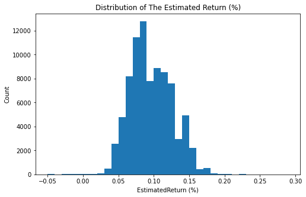

```python
# start with a standard-scaled plot
binsize = 0.01
bins = np.arange(-0.05, loan['EstimatedReturn'].max()+binsize, binsize)

plt.figure(figsize=[8, 5])
plt.hist(data = loan, x = 'EstimatedReturn', bins = bins)
plt.title('Distribution of The Estimated Return (%)')
plt.xlabel('EstimatedReturn (%)')
plt.ylabel('Count')

plt.show()
```

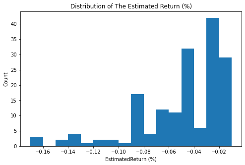

```python
# investigating further on an even smaller bin size
binsize = 0.01
bins = np.arange(-0.17, 0.00, 0.01)
plt.figure(figsize=[8,5])
plt.hist(data = loan, x = 'EstimatedReturn', bins = bins)
plt.title('Distribution of The Estimated Return (%)')
plt.xlabel('EstimatedReturn (%)')
plt.ylabel('Count')
plt.show()
```

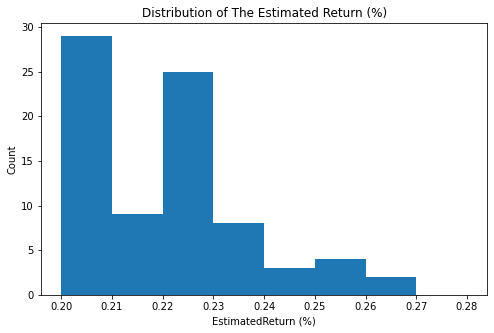

```python
# investigating further on an even smaller bin size considering the outliers
binsize = 0.01
bins = np.arange(0.2, 0.28, 0.01)
plt.figure(figsize=[8,5])
plt.hist(data = loan, x = 'EstimatedReturn', bins = bins)
plt.title('Distribution of The Estimated Return (%)')
plt.xlabel('EstimatedReturn (%)')
plt.ylabel('Count')
plt.show()
```

> These outliers are quite small compared to the actual size of the data and with this our analysis would be distorted, so we remove them to have a better veiw of the trend

```python
#outliers, using criteria eyeballed from the plots
loan.drop(loan[(loan['EstimatedReturn'] < 0.00) | (loan['EstimatedReturn'] > 0.21)].index, inplace=True)
#loan.shape
loan= loan[loan['EstimatedReturn'].notna()]
loan.shape
```

```
(84606, 81)
```

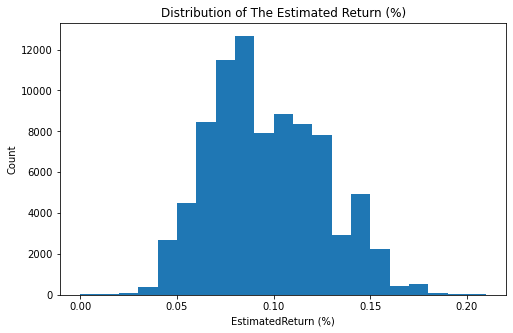

```python
# re-plot the distribution of EstimatedReturn
binsize = 0.01
bins = np.arange(0, loan['EstimatedReturn'].max()+binsize, binsize)

plt.figure(figsize=[8, 5])
plt.hist(data = loan, x = 'EstimatedReturn', bins = bins)
plt.title('Distribution of The Estimated Return (%)')
plt.xlabel('EstimatedReturn (%)')
plt.ylabel('Count')
plt.show()
```

> Next up, the first predictor variable of interest: BorrowerAPR, which is the cost paid each year to borrow money including fees, expressed in percentage. which has a minimum of 0.006530 and a maximum of 0.512290, that means every loan comes at some cost, from this we investigate the losses in the Estimated Return.

##### what is the distribution of the Borrower Annual Percantage rate in the Prosper loan dataset?

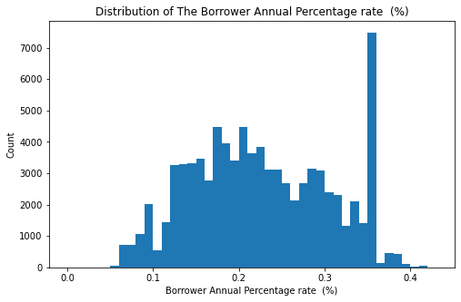

```python
# investigating with a standard-scaled plot
binsize = 0.01
bins = np.arange(0, loan['BorrowerAPR'].max()+binsize, binsize)

plt.figure(figsize=[8,5])
plt.hist(data = loan, x = 'BorrowerAPR', bins = bins)
plt.title('Distribution of The Borrower Annual Percentage rate  (%)')
plt.xlabel('Borrower Annual Percentage rate  (%)')
plt.ylabel('Count')
plt.show()
```

> From the above we can see a point around 0.36% which skewed higher breaking the symemetric distribution which goes down abruptly, acting abnormally. From this we would remove the null values

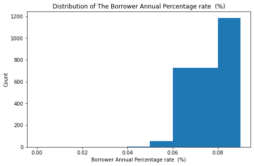

```python
# investigating further on an even smaller bin size
binsize = 0.01
bins = np.arange(0, 0.1, 0.01)

plt.figure(figsize=[8,5])
plt.hist(data = loan, x = 'BorrowerAPR', bins = bins)
plt.title('Distribution of The Borrower Annual Percentage rate  (%)')
plt.xlabel('Borrower Annual Percentage rate  (%)')
plt.ylabel('Count')
plt.show()
```

```python
loan['BorrowerAPR'].isnull().sum()

# we would look at these at set closely
low_rate = (loan['BorrowerAPR'] < 0.06)
print(loan.loc[low_rate,['BorrowerAPR','EstimatedReturn','EstimatedEffectiveYield','EstimatedLoss','BorrowerRate', 'LenderYield']])
```

```
        BorrowerAPR  EstimatedReturn  EstimatedEffectiveYield  EstimatedLoss  \
913         0.05927           0.0245                   0.0400         0.0155
1749        0.05927           0.0245                   0.0400         0.0155
1839        0.04583           0.0266                   0.0266         0.0060
3400        0.05927           0.0245                   0.0400         0.0155
5384        0.05927           0.0245                   0.0400         0.0155
8072        0.05525           0.0290                   0.0290         0.0130
9517        0.04935           0.0171                   0.0171         0.0130
12720       0.05927           0.0245                   0.0400         0.0155
17455       0.05927           0.0245                   0.0400         0.0155
20358       0.05335           0.0341                   0.0341         0.0060
25261       0.05927           0.0245                   0.0400         0.0155
28411       0.05927           0.0245                   0.0400         0.0155
28980       0.05927           0.0245                   0.0400         0.0155
29387       0.05927           0.0245                   0.0400         0.0155
```

[output cut: 102 more lines]

#### Let's look also at the Borrower Rate and its behaviour

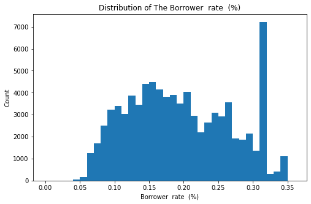

```python
# investigating Behaviour of The Borrower Rate in the Data Set
binsize = 0.01
bins = np.arange(0, loan['BorrowerRate'].max()+binsize, binsize)

plt.figure(figsize=[8,5])
plt.hist(data = loan, x = 'BorrowerRate', bins = bins)

plt.title('Distribution of The Borrower  rate  (%)')
plt.xlabel('Borrower  rate  (%)')
plt.ylabel('Count')
plt.show()
```

The BorrowerRate and the BorrowerAPR seems strong correlation and they look similar, and it ought to be since the later is the annual percentage rate. The both seems to be strongly hinged on the Lender Yeild.Lender yield is equal to the interest rate on the loan less the servicing fee. The Service Fees seems little. We would look more into this the Bivariate Exploration.

> Next we would be looking at the CurrentDelinquencies and its characters. It shows the number of accounts delinquent at the time the credit profile was pulled.

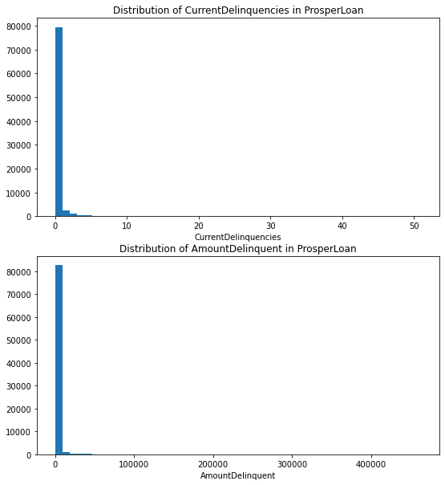

```python
# re-using code to plot some tables
variables = ['CurrentDelinquencies', 'AmountDelinquent']
g_size = len(variables)
fig, ax = plt.subplots(nrows=g_size, figsize = [9,10])

for i in range(len(variables)):
    var = variables[i]
    bins = np.arange(min(loan[var]), loan[var].max()+1, max(loan[var]) / 50)
    ax[i].hist(data = loan, x = var, bins = bins)
    ax[i].set_title( 'Distribution of {} in ProsperLoan'.format(var))
    ax[i].set_xlabel('{}'.format(var))

plt.show()
```

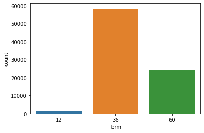

```python
#using a bar chart to see the Terms spent for the loans
sb.countplot(data=loan, x='Term');
```

```python
loan.AmountDelinquent.describe()
#it has a minimum of $0.00 and a maximum of $46,3881 and an average of $950
```

```
count     84606.000000
mean        949.134612
std        7418.348608
min           0.000000
25%           0.000000
50%           0.000000
75%           0.000000
max      463881.000000
Name: AmountDelinquent, dtype: float64
```

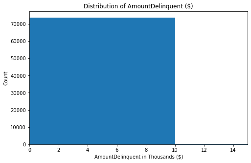

```python
#taking a closer look
binsize = 100
bins = np.arange(0,100, 10)
plt.figure(figsize=[8, 5])
plt.hist(data = loan, x = 'AmountDelinquent', bins = bins)
plt.title('Distribution of AmountDelinquent ($)')
plt.xlabel('AmountDelinquent in Thousands ($)')
plt.ylabel('Count')
plt.xlim([0, 15])
plt.show()
```

[figure not shown]

```python
# investigating with a log transform on AmountDelinquent axis
log_binsize = 0.25
bins = 10 ** np.arange(2.4, np.log10(loan['AmountDelinquent'].max())+log_binsize, log_binsize)

plt.figure(figsize=[8, 5])
plt.hist(data = loan, x = 'AmountDelinquent', bins = bins)
plt.xscale('log')
plt.xticks([500, 1e2, 2e3, 5e3, 1e5, 2e5], [500, '0', '3k', '5k', '7k', '10k'])
plt.title('Distribution of AmountDelinquent ($)')
plt.xlabel('AmountDelinquent in Thousands ($)')
plt.ylabel('Count')
plt.show()
```

The Amount Delinquent behaves more like the Current Delinquencies, Its tells us that most of the Delinquencies are Current, with a Few spread out on the other Loan statuses. We can see that the highest number of Current Delinquencies in the loan data is between 0-2 with a drastic fall after 1 to 2 point 9 which seem so rare. The terms here are spaced, because we have them in months i.e 12months (1year), 36 months (3years) and 60 months where 3years is the most common term in the Loan Data set. The AmountDeliquecies looks like the Currentdeliquencies, they seem to correlate. as the least value of amount seems to be the most common amount and the large amounts are very rare. This shows good management of Delinquencies from the ProsperLoan company.

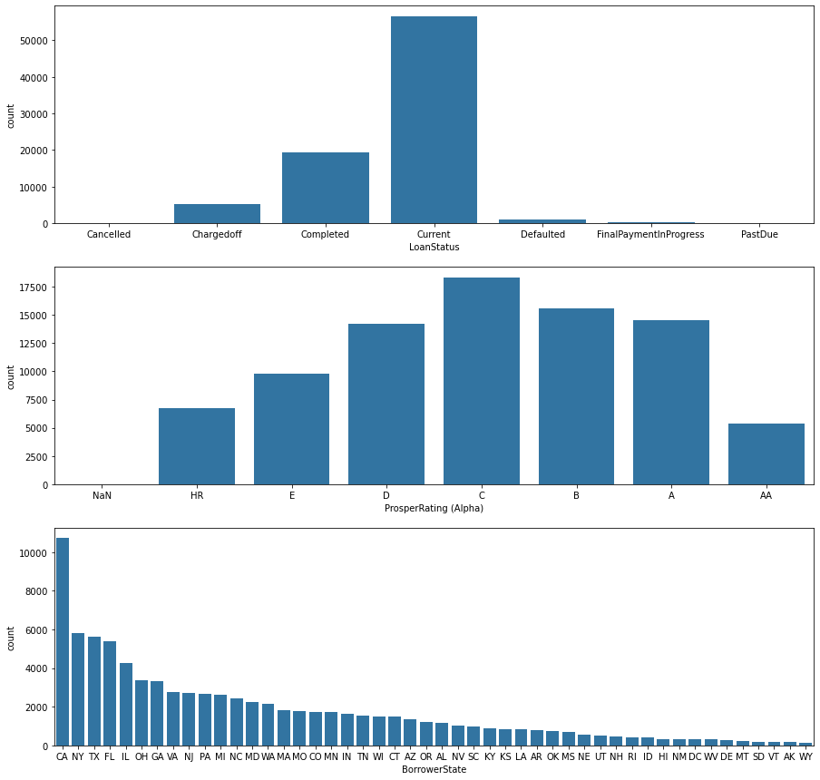

```python
# let's plot LoanStatus,ProsperRating and Borrower state to get an idea of each ordinal variable's distribution.

fig, ax = plt.subplots(nrows=3, figsize = [15,15])

default_color = sb.color_palette()[0]
sb.countplot(data = loan, x = 'LoanStatus', color = default_color, ax = ax[0])
sb.countplot(data = loan, x = 'ProsperRating (Alpha)', color = default_color, ax = ax[1])
sb.countplot(data = loan, x = 'BorrowerState', color = default_color, ax = ax[2], order=loan['BorrowerState'].value_counts().index)
plt.show()
```

We can see from the above that The company has more Curent Loan status and then followed by completed status it looks good, and considering the accounts in Current Delinquecy which is after comes along with the Pass Due Status, and looking at the Current Delinquencies, its just a small category in the Delinquencies, the ProsperLoan company is safe in business, and its noteworthy to know that Defaulted and Finalpaymentin progress borrowers are very little.Making it a safe balance for the Loan business From the Prosper rating we see that C has the most counts followed by B then A, the least count is the AA rating.The Prosper Rating assigned at the time the listing was created: 0 - N/A, 1 - HR, 2 - E, 3 - D, 4 - C, 5 - B, 6 - A, 7 - AA. Applicable for loans originated after July 2009. California (CA), NewYork (NY), and Texas (TX) is the top #3 Borrower State.

### Discuss the distribution(s) of your variable(s) of interest. Were there any unusual points? Did you need to perform any transformations?

> Borrower Annual Percentage Rate (%) has an unusual point around 0.36% as it has the highest count even when its quite a high percentage for cost of borrowing. The CurrentDeliquencies seem to be a category of Delinquencies which is sorted out delibrately by the company.

### Of the features you investigated, were there any unusual distributions? Did you perform any operations on the data to tidy, adjust, or change the form of the data? If so, why did you do this?

> When investigating the Estimated Returns alot of null values were removes which also removed null values from the Estimated Yeild and Estimate loss also the Properscore had null data.Also outliers were being removed from the data to focus more on the trend of the loans.

## Bivariate Exploration

> To start off with, I want to look at the pairwise correlations present between features in the data..

```python
numeric_vars = ['EstimatedReturn', 'BorrowerAPR', 'LenderYield', 'AmountDelinquent', 'CurrentDelinquencies', 'BorrowerRate', 'Term']
categoric_vars = ['LoanStatus', 'ProsperRating (Alpha)']
```

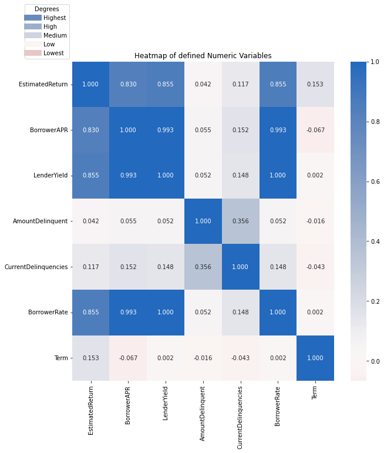

```python
# correlation plot

from matplotlib.lines import Line2D

plt.figure(figsize = [10,10])
sb.heatmap(loan[numeric_vars].corr(), annot = True, fmt = '.3f',
           cmap = 'vlag_r', center = 0)


color = list(sb.color_palette("vlag", 7))
custom_lines = []
for i in range(5):
    custom_lines.append(Line2D([0], [0], color=color[i], lw = 4))

plt.legend(custom_lines, ["Highest", "High", "Medium", "Low", "Lowest"], loc="lower right", bbox_to_anchor = (0,1), title="Degrees")
plt.title("Heatmap of defined Numeric Variables")
plt.show()
```

```
loan.shape= (84606, 81)
loan_samp.shape= (5000, 81)
```

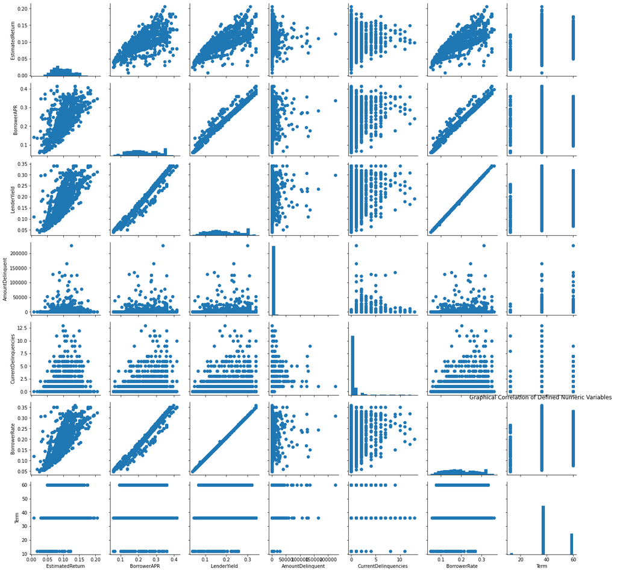

```python
# plot matrix: sample 5000 loans so that plots are clearer and they render faster
print("loan.shape=",loan.shape)
loan_samp = loan.sample(n=5000, replace = False)
print("loan_samp.shape=",loan_samp.shape)

g = sb.PairGrid(data = loan_samp, vars = numeric_vars)
g = g.map_diag(plt.hist, bins = 20);
g.map_offdiag(plt.scatter)

plt.title("Graphical Correlation of Defined Numeric Variables ")
```

```python
loan.corr()
```

|  | ListingNumber | Term | BorrowerAPR | BorrowerRate | LenderYield | EstimatedEffectiveYield | EstimatedLoss | EstimatedReturn | ListingCategory (numeric) | EmploymentStatusDuration | ... | LP_ServiceFees | LP_CollectionFees | LP_GrossPrincipalLoss | LP_NetPrincipalLoss | LP_NonPrincipalRecoverypayments | PercentFunded | Recommendations | InvestmentFromFriendsCount | InvestmentFromFriendsAmount | Investors |
| --- | --- | --- | --- | --- | --- | --- | --- | --- | --- | --- | --- | --- | --- | --- | --- | --- | --- | --- | --- | --- | --- |
| ListingNumber | 1.000000 | 0.188883 | -0.305303 | -0.320612 | -0.320527 | -0.229739 | -0.232688 | -0.490534 | -0.134378 | 0.079122 | ... | 0.430700 | 0.099064 | -0.187670 | -0.184771 | -0.068668 | 0.080896 | -0.072113 | -0.078089 | -0.042707 | -0.300975 |
| Term | 0.188883 | 1.000000 | -0.066647 | 0.001695 | 0.001726 | 0.054149 | -0.104225 | 0.153318 | -0.063399 | 0.052280 | ... | -0.205465 | 0.017763 | 0.041408 | 0.043218 | -0.012983 | -0.016770 | -0.029194 | -0.031048 | -0.014805 | 0.012181 |
| BorrowerAPR | -0.305303 | -0.066647 | 1.000000 | 0.993326 | 0.993327 | 0.914260 | 0.965263 | 0.830362 | 0.109453 | -0.039057 | ... | 0.124725 | -0.074120 | 0.126730 | 0.125221 | 0.059397 | -0.024305 | -0.013928 | -0.022709 | -0.005362 | -0.265329 |
| BorrowerRate | -0.320612 | 0.001695 | 0.993326 | 1.000000 | 0.999996 | 0.914267 | 0.960766 | 0.854745 | 0.104363 | -0.039102 | ... | 0.097919 | -0.076261 | 0.135555 | 0.134037 | 0.062252 | -0.030141 | -0.011815 | -0.018946 | -0.003108 | -0.242581 |
| LenderYield | -0.320527 | 0.001726 | 0.993327 | 0.999996 | 1.000000 | 0.914328 | 0.960775 | 0.854734 | 0.104369 | -0.039091 | ... | 0.097927 | -0.076247 | 0.135556 | 0.134039 | 0.062253 | -0.030146 | -0.011809 | -0.018942 | -0.003105 | -0.242626 |
| ... | ... | ... | ... | ... | ... | ... | ... | ... | ... | ... | ... | ... | ... | ... | ... | ... | ... | ... | ... | ... | ... |
| PercentFunded | 0.080896 | -0.016770 | -0.024305 | -0.030141 | -0.030146 | -0.043303 | -0.024329 | -0.040059 | -0.001087 | 0.007748 | ... | 0.082111 | 0.017977 | -0.038583 | -0.038890 | -0.011712 | 1.000000 | 0.004643 | -0.009533 | -0.000374 | -0.074269 |
| Recommendations | -0.072113 | -0.029194 | -0.013928 | -0.011815 | -0.011809 | -0.038556 | -0.009001 | -0.006439 | 0.000233 | -0.005925 | ... | -0.019385 | 0.000727 | -0.003142 | -0.003095 | -0.000773 | 0.004643 | 1.000000 | 0.457672 | 0.150456 | 0.034914 |
| InvestmentFromFriendsCount | -0.078089 | -0.031048 | -0.022709 | -0.018946 | -0.018942 | -0.053192 | -0.008620 | -0.024341 | -0.004086 | -0.013162 | ... | -0.028230 | -0.000186 | -0.004320 | -0.004161 | 0.000632 | -0.009533 | 0.457672 | 1.000000 | 0.447252 | 0.054092 |
| InvestmentFromFriendsAmount | -0.042707 | -0.014805 | -0.005362 | -0.003108 | -0.003105 | -0.028768 | 0.008287 | -0.017027 | -0.004038 | -0.004187 | ... | -0.016954 | 0.000834 | 0.001896 | 0.002075 | -0.001765 | -0.000374 | 0.150456 | 0.447252 | 1.000000 | 0.013567 |
| Investors | -0.300975 | 0.012181 | -0.265329 | -0.242581 | -0.242626 | -0.270552 | -0.280221 | -0.098795 | -0.045067 | -0.020156 | ... | -0.509667 | -0.035173 | 0.085386 | 0.083481 | 0.024235 | -0.074269 | 0.034914 | 0.054092 | 0.013567 | 1.000000 |

62 rows × 62 columns

From the above we can see a strong correlation between theBorrower rate,EstimatedReturn, and LenderYeild, these shows to affect each other, as the BorrowRate seem to have the strongest correlation with the LenderYield,The plots show that the BorrowerRate is depended on the LenderYeild. The BorrowerAPR is the LenderYeild plus the service Charges of Prosperloan. The Estimated Return is the expected profit to be made after deducting the Effectiveloss and Service Charge from the Estimated EffectiveYeild. Generally it shows that the Prosperloan company runs at profit as the Current Delinquencies shows to be in just a few account majorly in the range 0-5000 dollars which has an average of about $950 , and just rare cases above this. This shows proper management of loan. The major loan term is 3year followed by 5years.

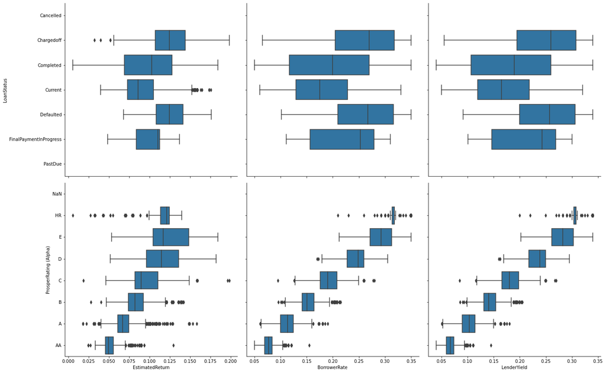

```python
# plot matrix of numeric features against categorical features.
# can use a larger sample since there are fewer plots and they're simpler in nature.

# Deprecated
#samples = np.random.choice(loan.shape[0], 5000, replace = False)
#loan_samp = loan.loc[samples,:]

loan_samp = loan.sample(n=5000, replace = False)


def boxgrid(x, y, **kwargs):

    sb.boxplot(x=x, y=y, color=default_color)

plt.figure(figsize = [10,10])
g = sb.PairGrid(data = loan_samp, y_vars = categoric_vars, x_vars = ['EstimatedReturn','BorrowerRate', 'LenderYield'],
                height = 6, aspect = 1)
g.map(boxgrid)
plt.show();
```

```python
#Selecting the Top 5 states to analyse
top_5_states = ['CA','NY','TX','FL','IL']
loan_bs = loan[loan.BorrowerState.isin(top_5_states) == True]
```

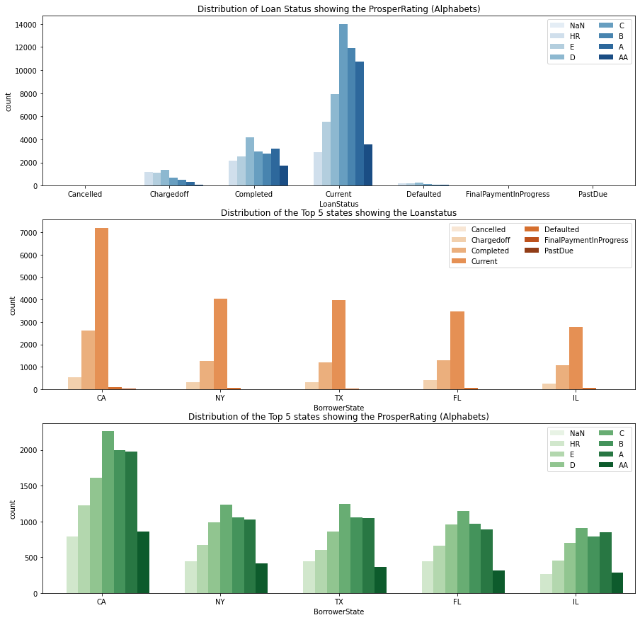

```python
# since there's only three subplots to create, using the Top 5 states to analyse.
plt.figure(figsize = [15,15])

# subplot 1: LoanStatus vs ProsperRating
ax = plt.subplot(3, 1, 1)
sb.countplot(data = loan, x = 'LoanStatus', hue = 'ProsperRating (Alpha)', palette = 'Blues')
ax.legend(loc = 1, ncol = 2)
plt.title("Distribution of Loan Status showing the ProsperRating (Alphabets)")

# subplot 2:Top 5 States vs loanStatus, use different color palette
ax = plt.subplot(3, 1, 2)
sb.countplot(data = loan_bs, x = 'BorrowerState', hue = 'LoanStatus', palette = 'Oranges', order=loan_bs['BorrowerState'].value_counts().index)
ax.legend(loc = 1, ncol = 2) # re-arrange legend to reduce overlapping
plt.title("Distribution of the Top 5 states showing the Loanstatus")

# subplot 3: Top 5 States vs loanStatus, use different color palette
ax = plt.subplot(3, 1, 3)
sb.countplot(data = loan_bs, x = 'BorrowerState', hue = 'ProsperRating (Alpha)', palette = 'Greens', order=loan_bs['BorrowerState'].value_counts().index)
ax.legend(loc = 1, ncol = 2) # re-arrange legend to remove overlapping
plt.title("Distribution of the Top 5 states showing the ProsperRating (Alphabets)")

plt.show()
```

The first plot tells us that the Current status and the completed status has the majority of all Proper rating, with C being the highest rate of point 4. For the Top 5 state we can see that CA is the most profitable state as it shows a high rate of current status and completed status verse Defaulted,

> The States follow almost the same trend of Rating as it raises form HR to the top C and the comes down to AA, except for IL(Illinois), which raises from HR to C, followed by A and the B down to AA.

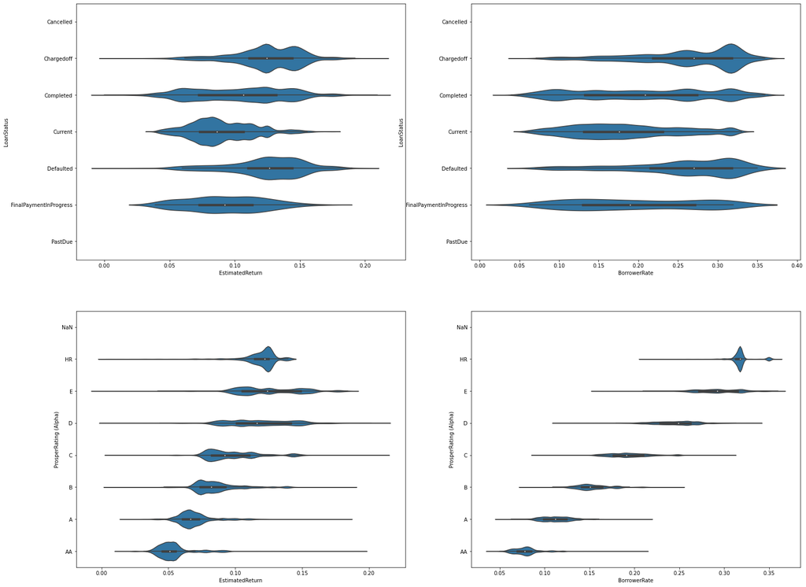

```python
# plot the categorical variables Estimated Return and Borrower rate, this time
# with full data and variable transforms
fig, ax = plt.subplots(ncols = 2, nrows = 2 , figsize = [25,20])
default_color = sb.color_palette()[0]
for i in range(len(categoric_vars)):
    var = categoric_vars[i]
    sb.violinplot(data = loan, x = 'EstimatedReturn', y = var, ax = ax[i,0], color = default_color)

    sb.violinplot(data = loan, x = 'BorrowerRate', y = var, ax = ax[i,1], color = default_color)

plt.show()
```

The loanStatus has been spread out across the EstimatedReturn and BorrowerRate, There is no major trend here, as these variables do not affect the status of the Loan.Cancelled and Past Due Status is Empty. Whereas the Prosper Rating has a trend especially for the Borrower rate, which shows the increase in rate from AA-HR, this comfirms the box plot we saw earlier.

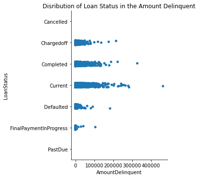

```python
#investigating AmountDelinquent and the Loan Status
sb.catplot(data= loan, x= 'AmountDelinquent', y= 'LoanStatus', color= default_color).set(title="Disribution of Loan Status in the Amount Delinquent")
```

From the above the categories in the Amount Delinquent, it is seen clearly as Current Delinquencies status are the hightest and focused om seperately by the ProsperLoan Company,Followed by Completed and then Charged off. Having Loan status on the Deliquencies, shows an eagle eye on the accounts.

[figure not shown]

```python
# scatter plot of AmountDelinquent vs. CurrentDelinquencies, with log transform on price axis
plt.figure(figsize = [8, 6])
plt.scatter(data = loan, x = 'CurrentDelinquencies', y = 'AmountDelinquent', alpha = 1/10)

plt.xlabel('CurrentDelinquencies')
plt.yscale('log')
plt.yticks([1e0, 1e1, 1e2, 1e3, 1e4, 1e5], [500, '1k', '2k', '4k', '8k', '10k'])
plt.title('Distribution of AmountDelinquent ($) in Current Delinquencies')
plt.ylabel('AmountDelinquent ($)')
plt.show()
```

### Talk about some of the relationships you observed in this part of the investigation. How did the feature(s) of interest vary with other features in the dataset?

> A strong correlation between the Borrower rate,EstimatedReturn, and LenderYeild, these shows to affect each other, as the BorrowRate seem to have the strongest correlation with the LenderYield,This tells that the BorrowerRate is depended on the LenderYeild. The BorrowerAPR is the LenderYeild plus the service Charges of Prosperloan. The Estimated Return is the expected profit to be made after deducting the Effectiveloss and Service Charge from the Estimated EffectiveYeild. It tells us that the service charge has little percentage and seems to be constant,as the Borrower rate an lenderyeild are strongly correlated. Generally it shows that the Prosperloan company runs at profit as the Current Delinquencies shows to be in just a few account majorly in the range 0-5000, and just rare cases above this. This shows proper management of loan. The major loan term is 3year followed by 5years., Which explains why majority of the accounts is in the Current Loan Status

### Did you observe any interesting relationships between the other features (not the main feature(s) of interest)?

> The most profitable state from the data is in Califonia (CA), it has the highest amount of Completed and Current Loan status, and very little Default. Also New York ad Texas. This information is good as more work can be targetted towards these states and VT(Vermont), AK(Alaska), WY(Wyoming) should have less focus.

## Multivariate Exploration

```python
def hist2dgrid(x, y, **kwargs):
    palette = kwargs.pop('color')
    bins_x = np.arange(0, 0.3, .01)
    bins_y = np.arange(0, 0.4+0.1, 0.01)
    plt.hist2d(x, y, bins = [bins_x, bins_y], cmap = palette, cmin = 0.5)
    plt.colorbar()
```

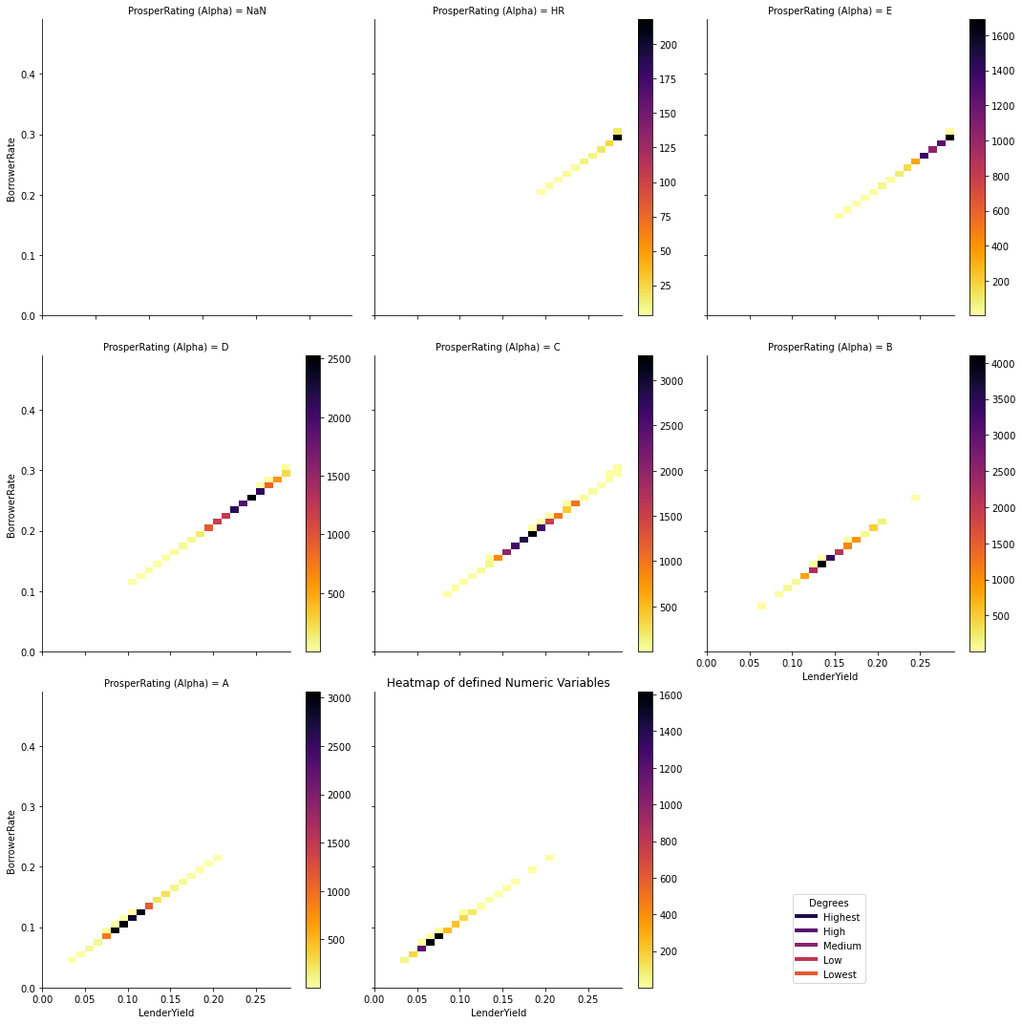

```python
g = sb.FacetGrid(data = loan, col = 'ProsperRating (Alpha)', col_wrap = 3, height = 5)
g.map(hist2dgrid, 'LenderYield', 'BorrowerRate', color = plt.cm.inferno_r)
color = list(sb.color_palette("inferno", 7))
custom_lines = []
for i in range(5):
    custom_lines.append(Line2D([0], [0], color=color[i], lw = 4))

plt.legend(custom_lines, ["Highest", "High", "Medium", "Low", "Lowest"], loc="lower right", bbox_to_anchor = (2,0), title="Degrees")
plt.title("Heatmap of defined Numeric Variables")

plt.show()
```

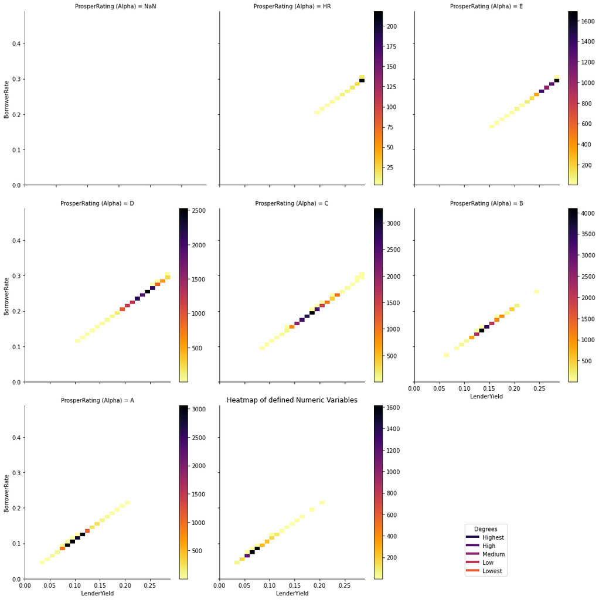

```python
g = sb.FacetGrid(data = loan, col = 'ProsperRating (Alpha)', col_wrap = 3, height = 5)
g.map(hist2dgrid, 'LenderYield', 'BorrowerRate', color = plt.cm.inferno_r)
custom_lines = []
for i in range(5):
    custom_lines.append(Line2D([0], [0], color=color[i], lw = 4))

plt.legend(custom_lines, ["Highest", "High", "Medium", "Low", "Lowest"], loc="lower right", bbox_to_anchor = (2,0), title="Degrees")
plt.title("Heatmap of defined Numeric Variables")

plt.show()
```

Depending on what the ratings are (The Prosper Rating assigned at the time the listing was created: 0 - N/A, 1 - HR, 2 - E, 3 - D, 4 - C, 5 - B, 6 - A, 7 - AA. Applicable for loans originated after July 2009.) It might have been a way to categorize things within the company. Looking closely, here its shows that the highest and lowest ratings have the lowest counts, but also see that the Lender yeild rate affects the Prosper ratings as AA- is the least below 0.10% as it increases up accordingly to HR the highest having concentrated rate after 0.2%

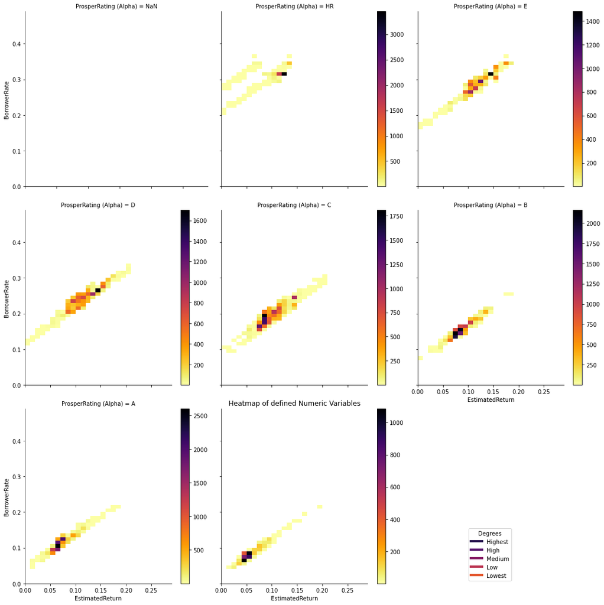

```python
g = sb.FacetGrid(data = loan, col = 'ProsperRating (Alpha)', col_wrap = 3, height = 5)
g.map(hist2dgrid, 'EstimatedReturn', 'BorrowerRate', color = plt.cm.inferno_r)
custom_lines = []
for i in range(5):
    custom_lines.append(Line2D([0], [0], color=color[i], lw = 4))

plt.legend(custom_lines, ["Highest", "High", "Medium", "Low", "Lowest"], loc="lower right", bbox_to_anchor = (2,0), title="Degrees")
plt.title("Heatmap of defined Numeric Variables")


plt.show()
```

The prosper rating against estimated return doesn't folow ay trend as such as HR and E ten to be in the same level, also D and C.

### Talk about some of the relationships you observed in this part of the investigation. Were there features that strengthened each other in terms of looking at your feature(s) of interest?

> The 2D graph faceted according to the Prosperratings confirmed the Lender yeild rate affects the Prosper ratings as AA- is the least below 0.10% as it increases up accordingly to HR the highest having concentrated rate after 0.2%

### Were there any interesting or surprising interactions between features?

> its interesting to see that Current Delinquencies have loan Status, so that means that the Current Deliquency is Number of accounts delinquent at the time the credit profile was pulled not necessarily the Status of the Delinquency.

## Conclusions

> The ProsperLoan Company seem to have a very good management and shows to be making its profits, even though the service charges seems to have a small percentage, it has more Completed and Current loan status. There is largely an estimate return of profit for all loans and very few losses. There was no trend with the CurrentDelinquencies to show why Customers fall in that category.

### References

> https://www.google.com/url?q=https://www.google.com/url?q%3Dhttps://s3.amazonaws.com/udacity-hosted-downloads/ud651/prosperLoanData.csv%26amp;sa%3DD%26amp;ust%3D1581581520570000&sa=D&source=editors&ust=1665050815945330&usg=AOvVaw12pLqWGmGQ4DWjG5mvmk6X www.google.com https://seaborn.pydata.org